# **Packages Used**

- **Pandas**: For data manipulation and processing pollutant data.
- **NumPy**: For numerical operations and handling pollutant values.
- **Matplotlib**: For generating static visualizations like bar and pie charts to display pollutant distribution.
- **Seaborn**: For advanced visualizations and enhancing chart aesthetics related to pollutant analysis.
- **Warnings**: To suppress non-critical warnings during the analysis.

# **Dataset Documentation:**

**Attribution of the Owner/Creator of the Data:**

This dataset is provided by **Data Society**, a platform that facilitates data-related resources and analysis. The data was created and made publicly available for educational and analytical purposes.

**Link to the Data:**

You can access the dataset through the following link: [US Air Pollution Data - Data Society](https://data.world/data-society/us-air-pollution-data)

**Summary Information About the Data:**

The dataset provides air pollution data for the United States, tracking the Air Quality Index (AQI) for several key pollutants: **NO2 (Nitrogen Dioxide)**, **O3 (Ozone)**, **SO2 (Sulfur Dioxide)**, and **CO (Carbon Monoxide)**. The data is collected from various states and cities across the U.S.

Key columns in the dataset include:

- **State**: The U.S. state where the data was recorded.
- **City**: The specific city within the state where measurements were taken.
- **NO2 AQI, O3 AQI, SO2 AQI, CO AQI**: The AQI values representing pollution levels for each pollutant.
- **Date**: The date on which the data was collected.

This dataset is useful for analyzing air pollution trends over time, comparing pollutant levels across different regions, and understanding the effects of various pollutants on air quality in the U.S.

# **Documentation of Changes Made to the Dataset:**

1. **Renaming Columns**: Replaced spaces in the entire dataset as well as column names with underscores (`_`) to ensure error-free calculations and consistency when referencing columns in the dataset.
2. **Removing Unnamed Columns**: Removed any unnamed columns from the dataset that were not needed for the analysis.
3. **Converting `Date_Local` to Proper DateTime Format**:
   - Transformed the `Date_Local` column into a datetime format using the following code:

     ```
     usap_file['Date_Local'] = pd.to_datetime(usap_file['Date_Local'], format='%d-%m-%Y', errors='coerce')
     ```

4. **Filtering the Dataset**:
   - Extracted data specific to California for the year 2010 using the following filter:

     ```
     usap = usap_file[(usap_file['State'] == 'California') & (usap_file['Date_Local'].dt.year == 2010)]
     ```

5. **Handling Null Values**:
   - The `City` column had many entries labeled as `'Not_in_a_city'`. These rows were isolated using the following code:

     ```
     not_in_a_city_data = usap[usap['City'] == 'Not_in_a_city']
     ```

   - The count of these rows was determined:

     ```
     not_in_a_city_count = len(not_in_a_city_data)
     ```

   - For these rows, I replaced `'Not_in_a_city'` with the city having the highest average **NO2 AQI**. This was achieved by calculating the mean **NO2 AQI** for each city and applying the replacement function:

     ```
     def replace_not_in_city(row):
         if row['City'] == 'Not_in_a_city':
             return city_avg_no2.idxmax()
         return row['City']
     ```

   - After applying this function, `'Not_in_a_city'` entries were replaced with the city having the highest average **NO2 AQI**.

These changes were made to clean up the dataset for visualization purposes and ensure that it was ready for analysis without further data cleaning tasks.

# **Part 1**

```python
import pandas as pd
import numpy as np
import matplotlib.pyplot as plt
import seaborn as sns
```

```python
# Suppress the FutureWarning
import warnings
warnings.filterwarnings("ignore", category=FutureWarning)
```

```python
from google.colab import drive

# Mount the Google Drive
drive.mount('/content/drive')
```

```python
file_path = '/content/drive/My Drive/Stats Project/pollution_us_2000_2016.csv'
usap_file = pd.read_csv(file_path)
```

```python
# Reset the index and drop the old one
usap_file.reset_index(drop=True, inplace=True)
usap_file.index += 1
```

```python
usap_file.head()
```

|  | Unnamed: 0 | State Code | County Code | Site Num | Address | State | County | City | Date Local | NO2 Units | ... | SO2 Units | SO2 Mean | SO2 1st Max Value | SO2 1st Max Hour | SO2 AQI | CO Units | CO Mean | CO 1st Max Value | CO 1st Max Hour | CO AQI |
| --- | --- | --- | --- | --- | --- | --- | --- | --- | --- | --- | --- | --- | --- | --- | --- | --- | --- | --- | --- | --- | --- |
| 1 | 0 | 4 | 13 | 3002 | 1645 E ROOSEVELT ST-CENTRAL PHOENIX STN | Arizona | Maricopa | Phoenix | 01-01-2000 | Parts per billion | ... | Parts per billion | 3.000000 | 9.0 | 21 | 13.0 | Parts per million | 1.145833 | 4.2 | 21 | NaN |
| 2 | 1 | 4 | 13 | 3002 | 1645 E ROOSEVELT ST-CENTRAL PHOENIX STN | Arizona | Maricopa | Phoenix | 01-01-2000 | Parts per billion | ... | Parts per billion | 3.000000 | 9.0 | 21 | 13.0 | Parts per million | 0.878947 | 2.2 | 23 | 25.0 |
| 3 | 2 | 4 | 13 | 3002 | 1645 E ROOSEVELT ST-CENTRAL PHOENIX STN | Arizona | Maricopa | Phoenix | 01-01-2000 | Parts per billion | ... | Parts per billion | 2.975000 | 6.6 | 23 | NaN | Parts per million | 1.145833 | 4.2 | 21 | NaN |
| 4 | 3 | 4 | 13 | 3002 | 1645 E ROOSEVELT ST-CENTRAL PHOENIX STN | Arizona | Maricopa | Phoenix | 01-01-2000 | Parts per billion | ... | Parts per billion | 2.975000 | 6.6 | 23 | NaN | Parts per million | 0.878947 | 2.2 | 23 | 25.0 |
| 5 | 4 | 4 | 13 | 3002 | 1645 E ROOSEVELT ST-CENTRAL PHOENIX STN | Arizona | Maricopa | Phoenix | 02-01-2000 | Parts per billion | ... | Parts per billion | 1.958333 | 3.0 | 22 | 4.0 | Parts per million | 0.850000 | 1.6 | 23 | NaN |

5 rows × 29 columns

```python
# Replace spaces with underscores in all column names
usap_file.columns = usap_file.columns.str.replace(' ', '_')
# Replace spaces with underscores in all string columns of the dataframe
usap_file = usap_file.apply(lambda x: x.str.replace(' ', '_') if x.dtype == "object" else x)

# converting Data_Local to peroper date time format to solve problem in
# perticular region
usap_file['Date_Local'] = pd.to_datetime(usap_file['Date_Local'], format='%d-%m-%Y', errors='coerce')

# filtering dataset
usap = usap_file[(usap_file['State'] == 'California') & (usap_file['Date_Local'].dt.year == 2010)].copy()
usap['Month'] = usap['Date_Local'].dt.month

# Check the updated dataframe
usap.head()
```

|  | Unnamed:_0 | State_Code | County_Code | Site_Num | Address | State | County | City | Date_Local | NO2_Units | ... | SO2_Mean | SO2_1st_Max_Value | SO2_1st_Max_Hour | SO2_AQI | CO_Units | CO_Mean | CO_1st_Max_Value | CO_1st_Max_Hour | CO_AQI | Month |
| --- | --- | --- | --- | --- | --- | --- | --- | --- | --- | --- | --- | --- | --- | --- | --- | --- | --- | --- | --- | --- | --- |
| 979466 | 11058 | 6 | 1 | 11 | 1100_21st_Street | California | Alameda | Oakland | 2010-12-13 | Parts_per_billion | ... | 0.575000 | 1.2 | 20 | 1.0 | Parts_per_million | 0.212500 | 0.4 | 18 | NaN | 12 |
| 979467 | 11059 | 6 | 1 | 11 | 1100_21st_Street | California | Alameda | Oakland | 2010-12-13 | Parts_per_billion | ... | 0.575000 | 1.2 | 20 | 1.0 | Parts_per_million | 0.146154 | 0.4 | 22 | 5.0 | 12 |
| 979468 | 11060 | 6 | 1 | 11 | 1100_21st_Street | California | Alameda | Oakland | 2010-12-13 | Parts_per_billion | ... | 0.650000 | 1.1 | 23 | NaN | Parts_per_million | 0.212500 | 0.4 | 18 | NaN | 12 |
| 979469 | 11061 | 6 | 1 | 11 | 1100_21st_Street | California | Alameda | Oakland | 2010-12-13 | Parts_per_billion | ... | 0.650000 | 1.1 | 23 | NaN | Parts_per_million | 0.146154 | 0.4 | 22 | 5.0 | 12 |
| 979470 | 11062 | 6 | 1 | 11 | 1100_21st_Street | California | Alameda | Oakland | 2010-12-14 | Parts_per_billion | ... | 2.095238 | 6.7 | 14 | 9.0 | Parts_per_million | 0.245455 | 0.6 | 23 | NaN | 12 |

5 rows × 30 columns

```python
usap.drop("Unnamed:_0", axis=1, inplace=True)
```

```python
usap.head(100000)
```

|  | State_Code | County_Code | Site_Num | Address | State | County | City | Date_Local | NO2_Units | NO2_Mean | ... | SO2_Mean | SO2_1st_Max_Value | SO2_1st_Max_Hour | SO2_AQI | CO_Units | CO_Mean | CO_1st_Max_Value | CO_1st_Max_Hour | CO_AQI | Month |
| --- | --- | --- | --- | --- | --- | --- | --- | --- | --- | --- | --- | --- | --- | --- | --- | --- | --- | --- | --- | --- | --- |
| 979466 | 6 | 1 | 11 | 1100_21st_Street | California | Alameda | Oakland | 2010-12-13 | Parts_per_billion | 14.443750 | ... | 0.575000 | 1.2 | 20 | 1.0 | Parts_per_million | 0.212500 | 0.4 | 18 | NaN | 12 |
| 979467 | 6 | 1 | 11 | 1100_21st_Street | California | Alameda | Oakland | 2010-12-13 | Parts_per_billion | 14.443750 | ... | 0.575000 | 1.2 | 20 | 1.0 | Parts_per_million | 0.146154 | 0.4 | 22 | 5.0 | 12 |
| 979468 | 6 | 1 | 11 | 1100_21st_Street | California | Alameda | Oakland | 2010-12-13 | Parts_per_billion | 14.443750 | ... | 0.650000 | 1.1 | 23 | NaN | Parts_per_million | 0.212500 | 0.4 | 18 | NaN | 12 |
| 979469 | 6 | 1 | 11 | 1100_21st_Street | California | Alameda | Oakland | 2010-12-13 | Parts_per_billion | 14.443750 | ... | 0.650000 | 1.1 | 23 | NaN | Parts_per_million | 0.146154 | 0.4 | 22 | 5.0 | 12 |
| 979470 | 6 | 1 | 11 | 1100_21st_Street | California | Alameda | Oakland | 2010-12-14 | Parts_per_billion | 22.250000 | ... | 2.095238 | 6.7 | 14 | 9.0 | Parts_per_million | 0.245455 | 0.6 | 23 | NaN | 12 |
| ... | ... | ... | ... | ... | ... | ... | ... | ... | ... | ... | ... | ... | ... | ... | ... | ... | ... | ... | ... | ... | ... |
| 1012701 | 6 | 95 | 4 | 304_TUOLUMNE_ST. | California | Solano | Vallejo | 2010-12-30 | Parts_per_billion | 11.956522 | ... | 0.385714 | 0.7 | 23 | NaN | Parts_per_million | 0.287500 | 0.5 | 23 | 6.0 | 12 |
| 1012702 | 6 | 95 | 4 | 304_TUOLUMNE_ST. | California | Solano | Vallejo | 2010-12-31 | Parts_per_billion | 12.943478 | ... | 0.834783 | 1.8 | 1 | 1.0 | Parts_per_million | 0.578261 | 1.6 | 1 | NaN | 12 |
| 1012703 | 6 | 95 | 4 | 304_TUOLUMNE_ST. | California | Solano | Vallejo | 2010-12-31 | Parts_per_billion | 12.943478 | ... | 0.834783 | 1.8 | 1 | 1.0 | Parts_per_million | 0.641667 | 1.2 | 5 | 14.0 | 12 |
| 1012704 | 6 | 95 | 4 | 304_TUOLUMNE_ST. | California | Solano | Vallejo | 2010-12-31 | Parts_per_billion | 12.943478 | ... | 0.757143 | 1.5 | 2 | NaN | Parts_per_million | 0.578261 | 1.6 | 1 | NaN | 12 |
| 1012705 | 6 | 95 | 4 | 304_TUOLUMNE_ST. | California | Solano | Vallejo | 2010-12-31 | Parts_per_billion | 12.943478 | ... | 0.757143 | 1.5 | 2 | NaN | Parts_per_million | 0.641667 | 1.2 | 5 | 14.0 | 12 |

33240 rows × 29 columns

```python
#Calculate the average NO2_AQI for each city
city_avg_no2 = usap.groupby('City')['NO2_AQI'].mean()

#Replace 'Not_in_a_city' with the average NO2_AQI value
def replace_not_in_city(row):
    if row['City'] == 'Not_in_a_city':
        return city_avg_no2.idxmax()  # Using the city with the highest average NO2_AQI as an example
    return row['City']

# Apply the function to replace 'Not_in_a_city'
usap['City'] = usap.apply(replace_not_in_city, axis=1)

# Check the updated dataset
print(usap[usap['City'] == 'Not_in_a_city'])
```

```
Empty DataFrame
Columns: [State_Code, County_Code, Site_Num, Address, State, County, City, Date_Local, NO2_Units, NO2_Mean, NO2_1st_Max_Value, NO2_1st_Max_Hour, NO2_AQI, O3_Units, O3_Mean, O3_1st_Max_Value, O3_1st_Max_Hour, O3_AQI, SO2_Units, SO2_Mean, SO2_1st_Max_Value, SO2_1st_Max_Hour, SO2_AQI, CO_Units, CO_Mean…
Index: []

[0 rows x 29 columns]
```

```python
# Filter the dataset to show rows where 'City' is 'Not_in_a_city'
not_in_a_city_data = usap[usap['City'] == 'Not_in_a_city']

# Count the total number of rows with 'Not_in_a_city'
not_in_a_city_count = len(not_in_a_city_data)

# Alternatively, using shape
# not_in_a_city_count = not_in_a_city_data.shape[0]

# Print the count
print(f"Total number of rows with 'Not_in_a_city' in the 'City' column: {not_in_a_city_count}")
```

```
Total number of rows with 'Not_in_a_city' in the 'City' column: 0
```

# **1. Two plots displaying the distribution of a single continuous variable**

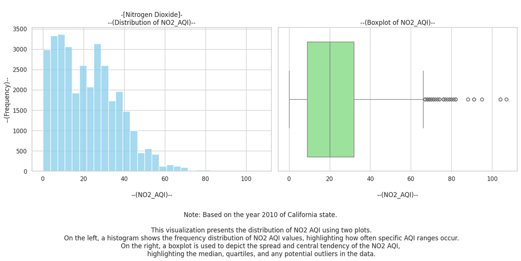

```python
# Set style for the plots
sns.set(style="whitegrid")

continuous_column = 'NO2_AQI'

# Create a 1-row, 2-column subplot for distribution plots
plt.figure(figsize=(14, 7))

# Histogram (first plot)
plt.subplot(1, 2, 1)
sns.histplot(usap[continuous_column], color='skyblue', bins=30)
plt.title(f'\n-[Nitrogen Dioxide]-\n--(Distribution of {continuous_column})--')
plt.xlabel(f'\n--({continuous_column})--\n\n\n\n\n\n\n')
plt.ylabel('--(Frequency)--')

# Boxplot (second plot)
plt.subplot(1, 2, 2)
sns.boxplot(x=usap[continuous_column], color='lightgreen')
plt.title(f'--(Boxplot of {continuous_column})--')
plt.xlabel(f'\n--({continuous_column})--')

#caption
plt.figtext(0.5, 0.02,
            "Note: Based on the year 2010 of California state.\n\n "
           "This visualization presents the distribution of NO2 AQI using two plots.\n "
           "On the left, a histogram shows the frequency distribution of NO2 AQI values, highlighting how often specific AQI ranges occur.\n"
           "On the right, a boxplot is used to depict the spread and central tendency of the NO2 AQI,\n "
           "highlighting the median, quartiles, and any potential outliers in the data.",
           wrap=True, horizontalalignment='center', fontsize=12)
# Adjust layout for clarity and show the plot
plt.tight_layout()
plt.show()
```

# **2.Two plots displaying information about a single categorical variable**

```python
usap.State.unique()
```

```
array(['California'], dtype=object)
```

[figure not shown]

```python
sns.set(style="whitegrid")

# Get top 5 states and filter data
top_states = usap['City'].value_counts().nlargest(5).index
filtered_data = usap[usap['City'].isin(top_states)]

plt.figure(figsize=(14, 8))

# Bar plot (use the same color with pie chart)
state_counts = usap["City"].value_counts().nlargest(5)
custom_colors = ["#4ecb8d","#326b77", "#568b87", "#80ae9a", "#b5d1ae"]

# Bar plot (1st Plot)
plt.subplot(1, 2, 1)
sns.barplot(x=state_counts.index, y=state_counts.values, palette=custom_colors)
plt.title('\n\n\n--(Top 5, States by number of occurrences (count)--')
plt.xlabel('\n--(Cities)--\n\n\n\n\n')
plt.ylabel('\n--(Count)--')

# Pie chart (2nd Plot)
plt.subplot(1, 2, 2)
plt.title("--(Proportion of Data by City)--")
plt.pie(
    state_counts.values, labels=state_counts.index, autopct='%1.1f%%', startangle=90,
    colors=custom_colors[:len(state_counts)],
    wedgeprops=dict(edgecolor='black')
)

#caption
plt.figtext(0.5, 0.02,
           "This figure displays two visualizations for the top 5 states based on count in the dataset.\n "
           "The bar plot on the left shows the number of occurrences for each state,\n while the pie chart on "
           "the right illustrates the proportion of each state’s data in relation to the total.\n Both plots use "
           "consistent color schemes to enhance comparison.",
           wrap=True, horizontalalignment='center', fontsize=12)

plt.tight_layout()
plt.show()
```